# Lesson 7: Linear Regression

Siim Põldre

12/11/2020

## Lesson 7.2

### Data

Näitena vaatame Leinhardt andmeid R-i car pakis

```r
library("car")
data("Leinhardt")
?Leinhardt
head(Leinhardt)
```

```
##           income infant   region oil
## Australia   3426   26.7     Asia  no
## Austria     3350   23.7   Europe  no
## Belgium     3346   17.0   Europe  no
## Canada      4751   16.8 Americas  no
## Denmark     5029   13.5   Europe  no
## Finland     3312   10.1   Europe  no
```

```r
str(Leinhardt)
```

```
## 'data.frame':    105 obs. of  4 variables:
##  $ income: int  3426 3350 3346 4751 5029 3312 3403 5040 2009 2298 ...
##  $ infant: num  26.7 23.7 17 16.8 13.5 10.1 12.9 20.4 17.8 25.7 ...
##  $ region: Factor w/ 4 levels "Africa","Americas",..: 3 4 4 2 4 4 4 4 4 4 ...
##  $ oil   : Factor w/ 2 levels "no","yes": 1 1 1 1 1 1 1 1 1 1 ...
```

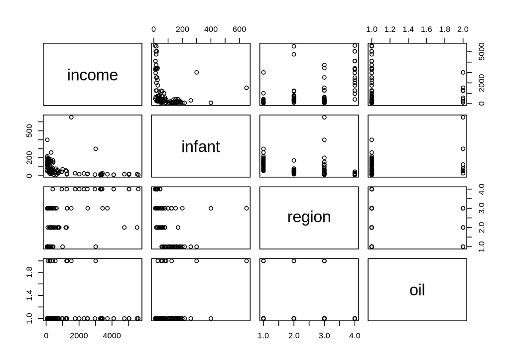

```r
pairs(Leinhardt)
```

Alustame lihtsa lineaarse regressiooni mudeliga, mis seob imikusuremuse per capita sissetulekuga

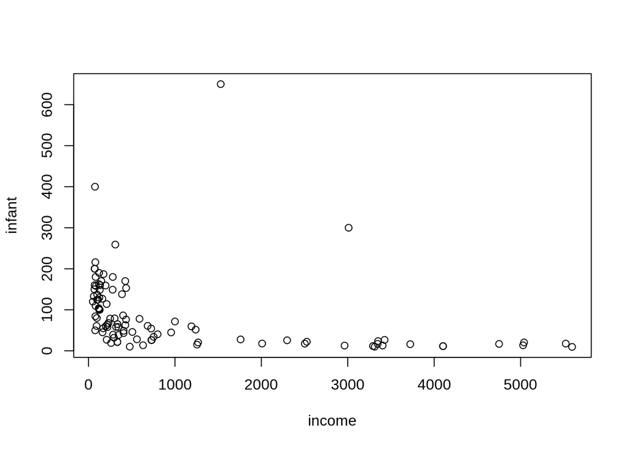

```r
plot(infant ~ income, data=Leinhardt)
```

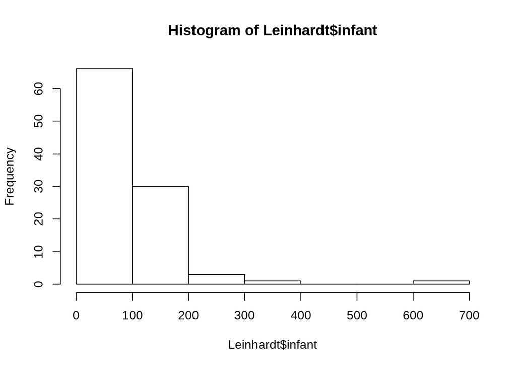

```r
hist(Leinhardt$infant)
```

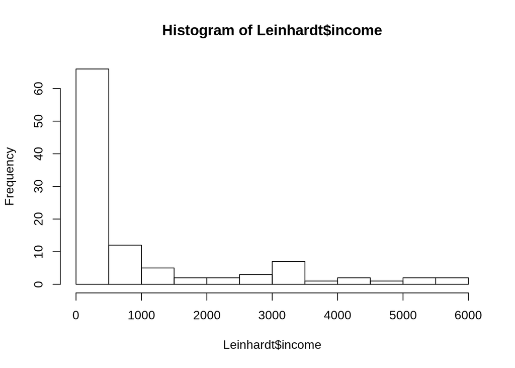

```r
hist(Leinhardt$income)
```

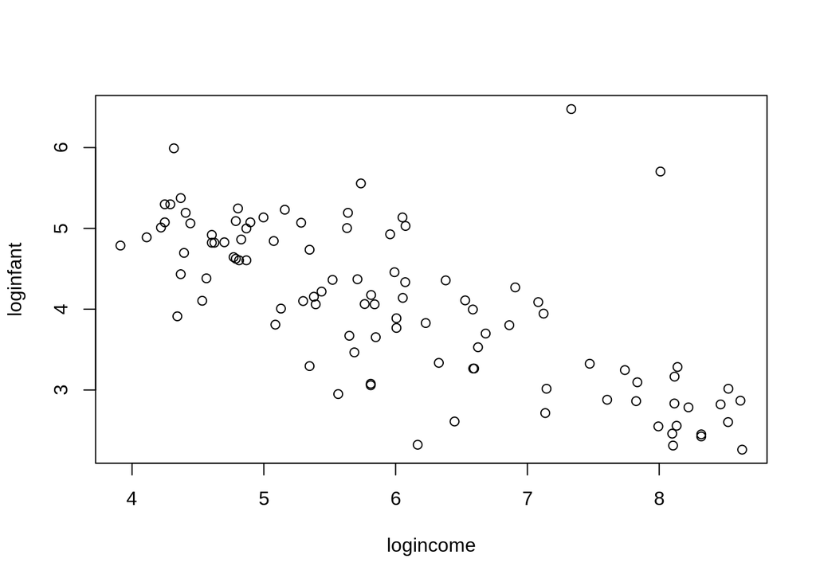

```r
Leinhardt$loginfant = log(Leinhardt$infant)
Leinhardt$logincome = log(Leinhardt$income)

plot(loginfant ~ logincome, data=Leinhardt)
```

Kuna imikusuremus ja per capita sissetulek on positiivsed ja paremale poole kaldu suurused, siis kaalume nende mudeldamist logaritmilisel skaalal. Lineaarne mudel tundub sellel skaalal palju sobivam.

### Mudeldamine

Viidatav Bayesi analüüs (mitte-informatiivse prioriga) on otse R-is saadaval:

```r
lmod = lm(loginfant ~ logincome, data=Leinhardt)
summary(lmod)
```

```
##
## Call:
## lm(formula = loginfant ~ logincome, data = Leinhardt)
##
## Residuals:
##      Min       1Q   Median       3Q      Max
## -1.66694 -0.42779 -0.02649  0.30441  3.08415
##
## Coefficients:
##             Estimate Std. Error t value Pr(>|t|)
## (Intercept)  7.14582    0.31654  22.575   <2e-16 ***
## logincome   -0.51179    0.05122  -9.992   <2e-16 ***
## ---
## Signif. codes:  0 '***' 0.001 '**' 0.01 '*' 0.05 '.' 0.1 ' ' 1
##
## Residual standard error: 0.6867 on 99 degrees of freedom
##   (4 observations deleted due to missingness)
## Multiple R-squared:  0.5021, Adjusted R-squared:  0.4971
## F-statistic: 99.84 on 1 and 99 DF,  p-value: < 2.2e-16
```

##Lesson 7.3

### Mudel JAGS-is

Kuna osad väärtused on puudu, siis jätame nad lihtalt välja

```r
dat = na.omit(Leinhardt)

library("rjags")
mod1_string = " model {
    for (i in 1:n) {
        y[i] ~ dnorm(mu[i], prec)
        mu[i] = b[1] + b[2]*log_income[i]
    }

    for (i in 1:2) {
        b[i] ~ dnorm(0.0, 1.0/1.0e6)
    }

    prec ~ dgamma(5/2.0, 5*10.0/2.0)
    sig2 = 1.0 / prec
    sig = sqrt(sig2)
} "

set.seed(72)
data1_jags = list(y=dat$loginfant, n=nrow(dat),
              log_income=dat$logincome)

params1 = c("b", "sig")

inits1 = function() {
    inits = list("b"=rnorm(2,0.0,100.0), "prec"=rgamma(1,1.0,1.0))
}

mod1 = jags.model(textConnection(mod1_string), data=data1_jags, inits=inits1, n.chains=3)
update(mod1, 1000) # burn-in

mod1_sim = coda.samples(model=mod1,
                        variable.names=params1,
                        n.iter=5000)

mod1_csim = do.call(rbind, mod1_sim) # combine multiple chains
```

## Lesson 7.4

### MCMC convergence

Enne kui me vaatame mudelist tehtavaid järeldusi, peaksime viima läbi convergence diagnostikat oma Markovi ahelatele

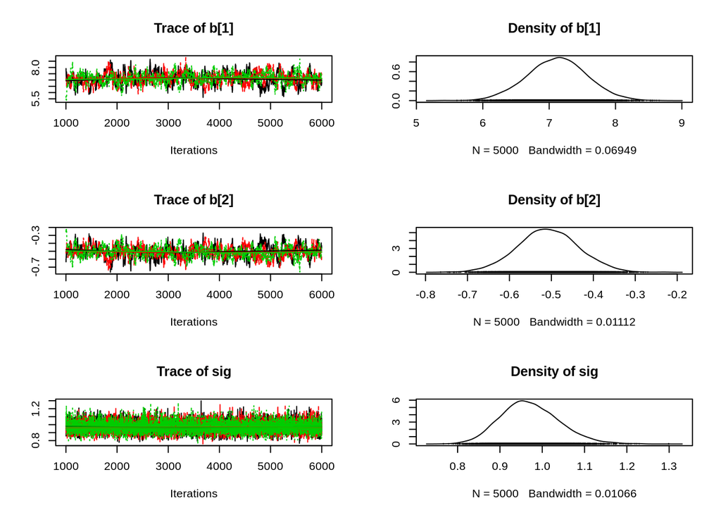

```r
plot(mod1_sim)
```

```r
gelman.diag(mod1_sim)
```

```
## Potential scale reduction factors:
##
##      Point est. Upper C.I.
## b[1]       1.01       1.04
## b[2]       1.01       1.04
## sig        1.00       1.00
##
## Multivariate psrf
##
## 1.01
```

```r
autocorr.diag(mod1_sim)
```

```
##             b[1]      b[2]        sig
## Lag 0  1.0000000 1.0000000 1.00000000
## Lag 1  0.9526523 0.9525955 0.01187062
## Lag 5  0.7789905 0.7804864 0.02738084
## Lag 10 0.6079532 0.6113133 0.01345915
## Lag 50 0.1144382 0.1128621 0.01943050
```

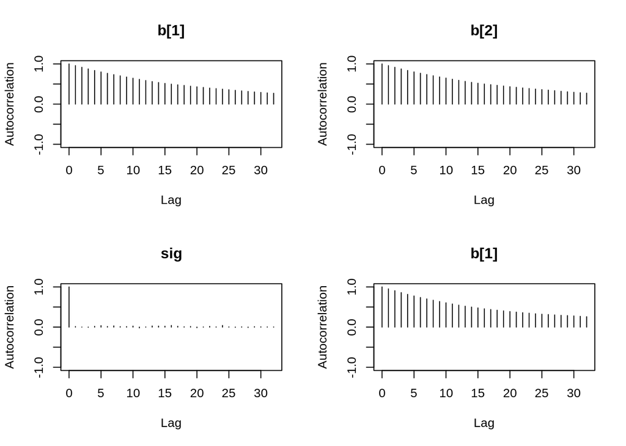

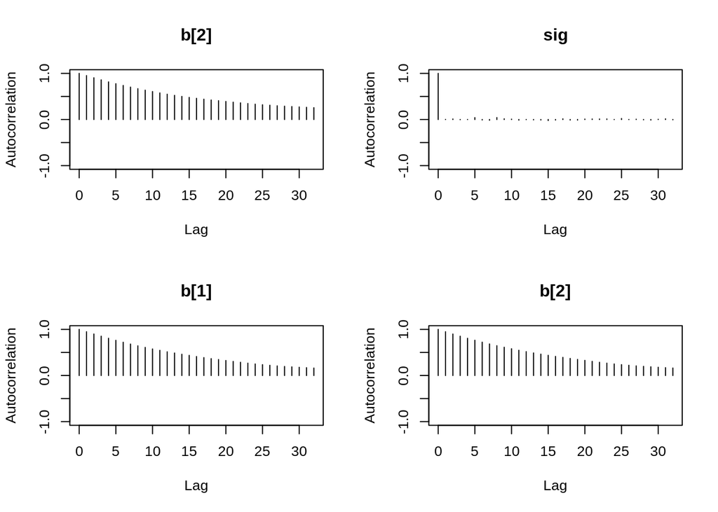

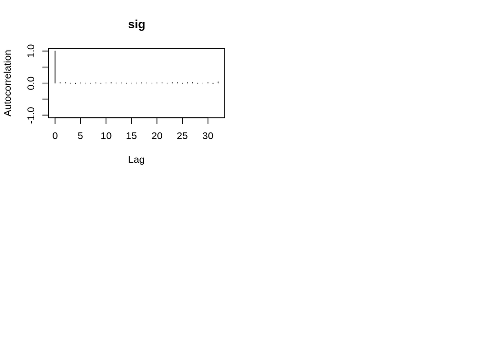

```r
autocorr.plot(mod1_sim)
```

```r
effectiveSize(mod1_sim)
```

```
##       b[1]       b[2]        sig
##   376.9703   364.1508 12306.6709
```

Meil on võimalik saada järeljaotuse kokkuvõte oma mudeli parameetritest

```r
summary(mod1_sim)
```

```
##
## Iterations = 1001:6000
## Thinning interval = 1
## Number of chains = 3
## Sample size per chain = 5000
##
## 1. Empirical mean and standard deviation for each variable,
##    plus standard error of the mean:
##
##         Mean      SD  Naive SE Time-series SE
## b[1]  7.1203 0.44975 0.0036722      0.0233117
## b[2] -0.5076 0.07267 0.0005934      0.0038349
## sig   0.9714 0.06899 0.0005633      0.0006322
##
## 2. Quantiles for each variable:
##
##         2.5%     25%     50%     75%   97.5%
## b[1]  6.2304  6.8198  7.1265  7.4209  8.0061
## b[2] -0.6500 -0.5560 -0.5081 -0.4598 -0.3646
## sig   0.8474  0.9235  0.9669  1.0157  1.1175
```

Tuleb siiski meeles pidada, et need tulemused on regressiooni mudelile, mis seostavad imikusuremuse LOGARITMI sissetuleku LOGAERITMIGA

### Jääkide üle vaatamine

Jääkida üle vaatamine on lineaarsete mudelite puhul oluline, kuna jäägid võivad meile näidata mudeli loomisel tehtud eelduste rikkumist, Me otsime märke sellest, et mudel ei ole lineaarne, normaaljaotusega, või ei vaatlused ei ole sõltumatud (*conditional on covariates*).

Esmalt vaatame, mis oleks juhtunud, kui me sobitaks reference lineaarse mudeli transformeerimata muutujatele:

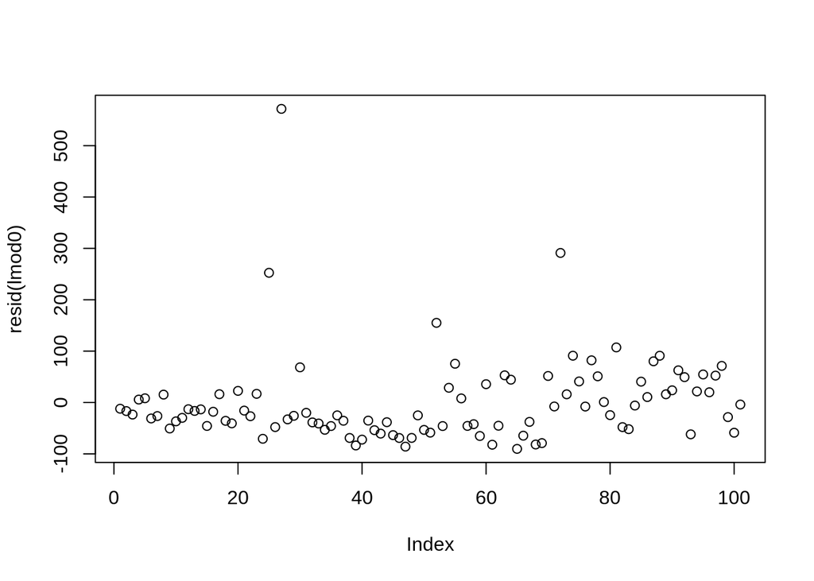

```r
lmod0 = lm(infant ~ income, data=Leinhardt)
plot(resid(lmod0)) # to check independence (looks okay)
```

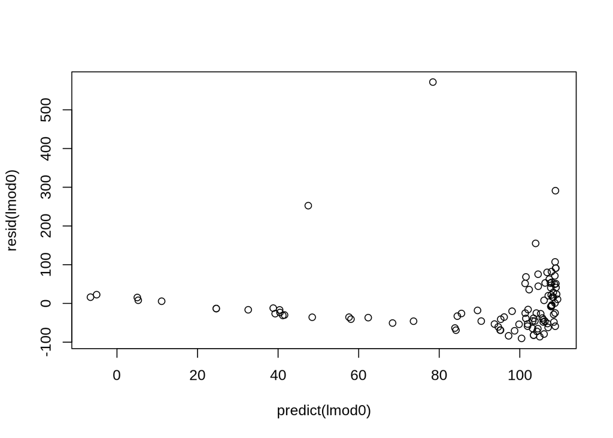

```r
plot(predict(lmod0), resid(lmod0)) # to check for linearity, constant variance (looks bad)
```

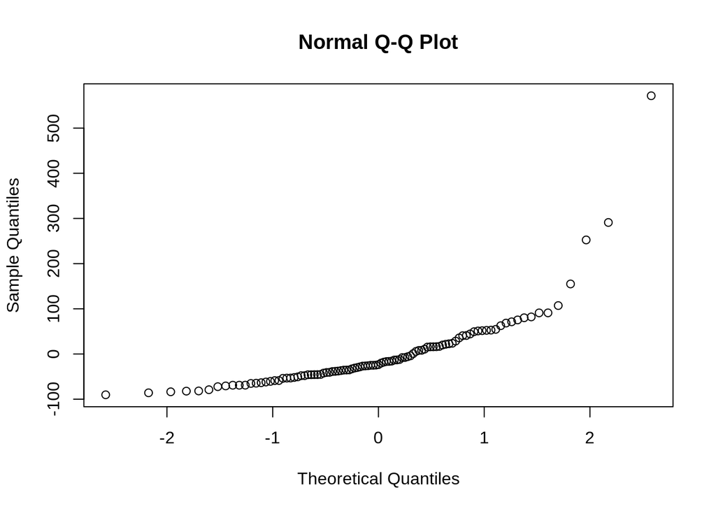

```r
qqnorm(resid(lmod0)) # to check Normality assumption (we want this to be a straight line)
```

Nüüd vaatame oma mudelit, mille sobitasime log-transformeeritud muutujatele. bayesi mudeli puhul on meil jääkide jaoks jaotused, kuid me vaatama lihtsuse mõttes ainult jääke, mida on hinnatud parameetrite järeljaotusejärgse keskmise juures.

```r
X = cbind(rep(1.0, data1_jags$n), data1_jags$log_income)
head(X)
```

```
##      [,1]     [,2]
## [1,]    1 8.139149
## [2,]    1 8.116716
## [3,]    1 8.115521
## [4,]    1 8.466110
## [5,]    1 8.522976
## [6,]    1 8.105308
```

```r
(pm_params1 = colMeans(mod1_csim)) # posterior mean
```

```
##       b[1]       b[2]        sig
##  7.1203018 -0.5076189  0.9714208
```

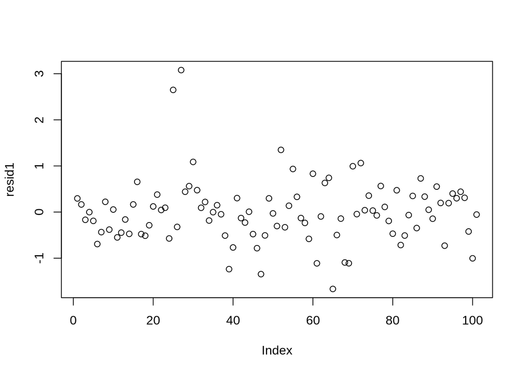

```r
yhat1 = drop(X %*% pm_params1[1:2])
resid1 = data1_jags$y - yhat1
plot(resid1) # against data index
```

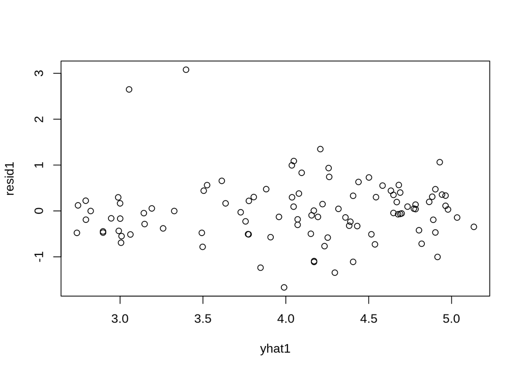

```r
plot(yhat1, resid1) # against predicted values
```

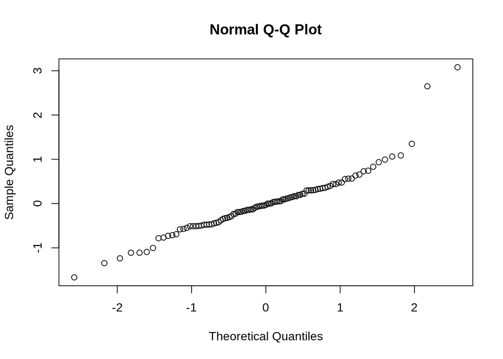

```r
qqnorm(resid1) # checking normality of residuals
```

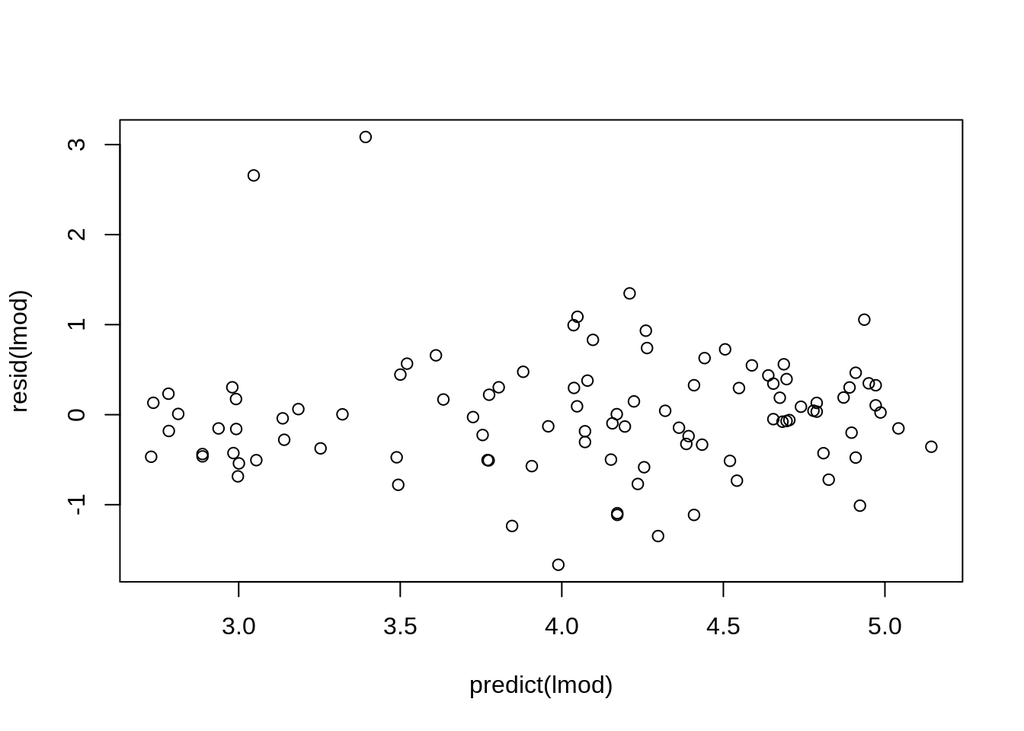

```r
plot(predict(lmod), resid(lmod)) # to compare with reference linear model
```

```r
rownames(dat)[order(resid1, decreasing=TRUE)[1:5]] # which countries have the largest positive residuals?
```

```
## [1] "Saudi.Arabia" "Libya"        "Zambia"       "Brazil"       "Afganistan"
```

Jäägid näevad suhteliselt head välja (pole mingeid selgeid mustreid). väljaarvatud kaks suurt *outlier*it, Saudi Arabia ja Libya. *Outlier*ite puhul on hea idee vaadata üle, et nad poleks lihtsalt andmete sisestamisel tehtud vead. Kui väärtused on õiged, iis tuleks mõelda sellele, kas need andmepunktid on tõesti mudeldatava andmestiku suhtes esinduslikud. Kui järeldus on, et pole (nt nad salvestatierinevatel aastatel), siis võib õigustada nende eemaldamist andmetest.

Kui järelduseks on, et need *outlier*id on andmete osa ja neid ei tohiks eemaldada, siis on meil erinevaid võimalusi, et neid kaasata. Sellest räägime järgmises osas.

## Lesson 7.5

### Lisanduvad kovariaadid

Esimeseks lahenduseks on otsida lisa kovriaate, mis võiksid selgitada outlier’ite olemasolu. Näiteks võib olla mitmeid muutujaid, mis annavad imikusuremuse kohta informatsiooni palju rohkem kui sissetulekud.

Vaadates oma andmeid uuesti, on meil kaks tunnust, mida me pole veel kasutanud: “region” ja “oil”. “oil” märgib naftariike. Nii Saudi-Araabia kui ka Liibüa on naftariigid. Seega on võimalik, et see võib meie anomaaliat selgitada.

```r
library("rjags")

mod2_string = " model {
    for (i in 1:length(y)) {
        y[i] ~ dnorm(mu[i], prec)
        mu[i] = b[1] + b[2]*log_income[i] + b[3]*is_oil[i]
    }

    for (i in 1:3) {
        b[i] ~ dnorm(0.0, 1.0/1.0e6)
    }

    prec ~ dgamma(5/2.0, 5*10.0/2.0)
    sig = sqrt( 1.0 / prec )
} "


set.seed(73)
data2_jags = list(y=dat$loginfant, log_income=dat$logincome,
                  is_oil=as.numeric(dat$oil=="yes"))
data2_jags$is_oil
```

```
##   [1] 0 0 0 0 0 0 0 0 0 0 0 0 0 0 0 0 0 0 0 0 1 1 1 1 1 1 1 1 0 0 0 0 0 0 0 0 0
##  [38] 0 0 0 0 0 0 0 0 0 0 0 0 0 0 0 0 0 0 0 0 0 0 0 0 0 0 0 0 0 0 0 0 0 0 0 0 0
##  [75] 0 0 0 0 0 0 0 0 0 0 0 0 0 0 0 0 0 0 0 0 0 0 0 0 0 0 0
```

```r
params2 = c("b", "sig")

inits2 = function() {
    inits = list("b"=rnorm(3,0.0,100.0), "prec"=rgamma(1,1.0,1.0))
}

mod2 = jags.model(textConnection(mod2_string), data=data2_jags, inits=inits2, n.chains=3)
update(mod2, 1e3) # burn-in

mod2_sim = coda.samples(model=mod2,
                        variable.names=params2,
                        n.iter=5e3)

mod2_csim = as.mcmc(do.call(rbind, mod2_sim)) # combine multiple chains
```

Nagu ikka, vaatame ka *convergence*i diagnostikat

[figure not shown]

```r
plot(mod2_sim)
```

```r
gelman.diag(mod2_sim)
```

```
## Potential scale reduction factors:
##
##      Point est. Upper C.I.
## b[1]       1.05       1.14
## b[2]       1.05       1.14
## b[3]       1.00       1.00
## sig        1.00       1.00
##
## Multivariate psrf
##
## 1.03
```

```r
autocorr.diag(mod2_sim)
```

```
##              b[1]       b[2]        b[3]          sig
## Lag 0  1.00000000 1.00000000  1.00000000  1.000000000
## Lag 1  0.94963145 0.95044316  0.07916314  0.020792516
## Lag 5  0.77353516 0.77430310 -0.01092771  0.013522645
## Lag 10 0.60165006 0.60103340  0.01197731 -0.007526373
## Lag 50 0.06183842 0.06458843  0.00059522 -0.003074837
```

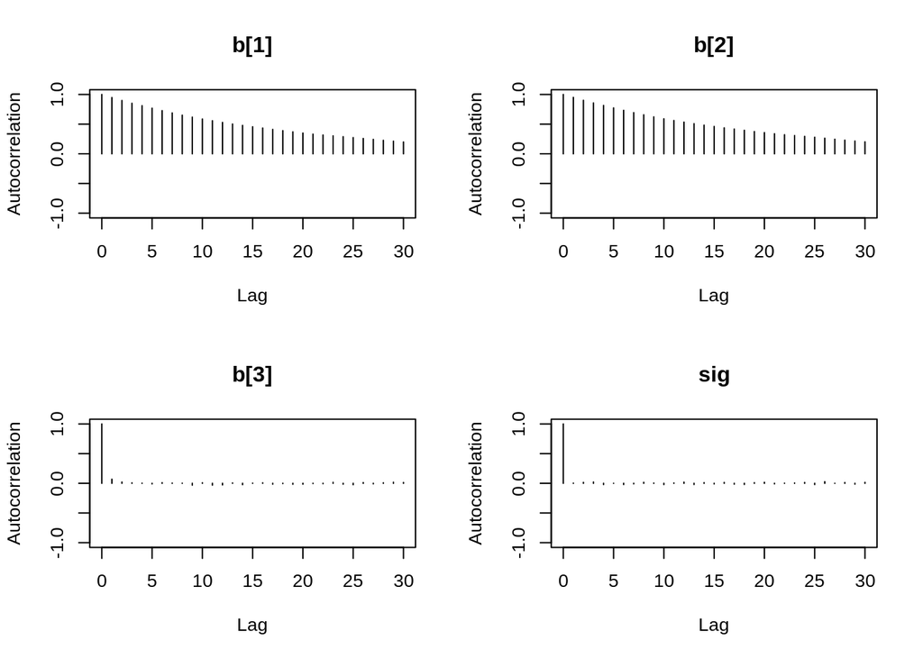

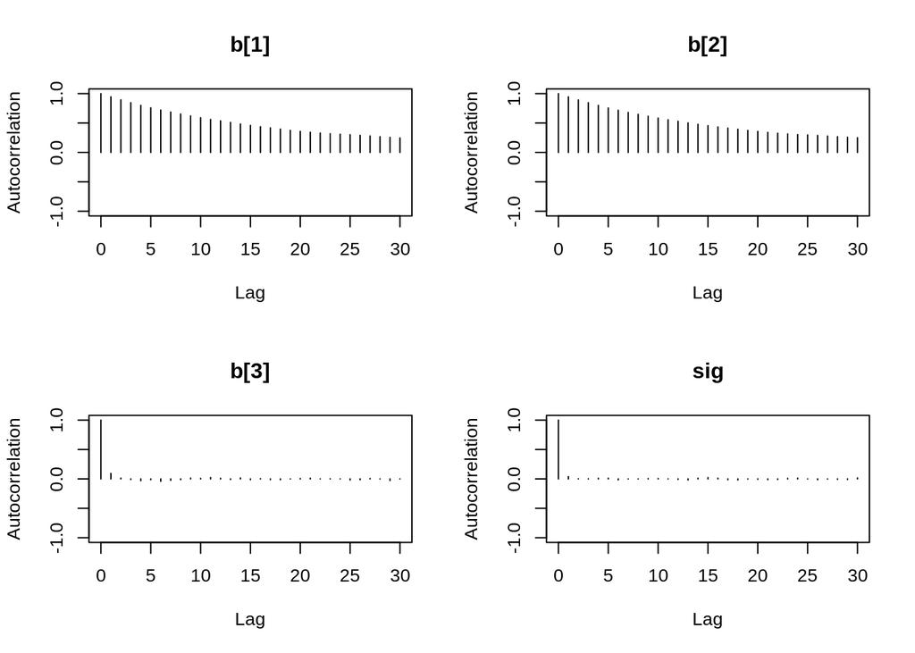

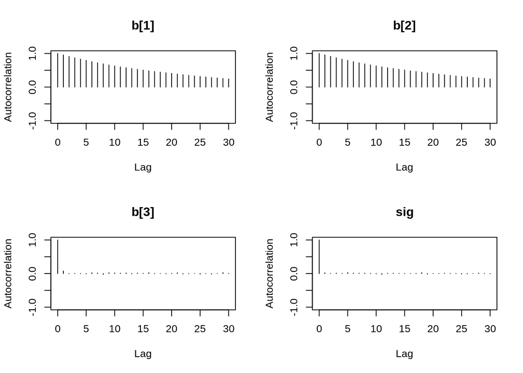

```r
autocorr.plot(mod2_sim)
```

```r
effectiveSize(mod2_sim)
```

```
##       b[1]       b[2]       b[3]        sig
##   384.7126   381.1380 13542.0150 14417.9434
```

Järeljaotuse parameetrite kokkuvõte on siin

```r
summary(mod2_sim)
```

```
##
## Iterations = 1001:6000
## Thinning interval = 1
## Number of chains = 3
## Sample size per chain = 5000
##
## 1. Empirical mean and standard deviation for each variable,
##    plus standard error of the mean:
##
##         Mean      SD  Naive SE Time-series SE
## b[1]  7.1361 0.43008 0.0035116      0.0219709
## b[2] -0.5206 0.06981 0.0005700      0.0035872
## b[3]  0.7864 0.35523 0.0029005      0.0030572
## sig   0.9525 0.06667 0.0005444      0.0005553
##
## 2. Quantiles for each variable:
##
##          2.5%     25%     50%     75%   97.5%
## b[1]  6.30245  6.8481  7.1385  7.4167  7.9830
## b[2] -0.65976 -0.5669 -0.5208 -0.4737 -0.3847
## b[3]  0.08823  0.5467  0.7824  1.0245  1.4901
## sig   0.83141  0.9065  0.9487  0.9954  1.0937
```

Tundub, et nafta toomise ja log-imikusuremuse vahel opn positiivne seos. Kuna need andmed on ainult vaatluslikud, siis me ei saa öelda, et nafta tootmine tekitab imikusuremust (see ei ole tõenäoliselt nii), kuid me saame öelda, et nad on positiivses seoses.

Nüüd vaatame jääke

```r
X2 = cbind(rep(1.0, data1_jags$n), data2_jags$log_income, data2_jags$is_oil)
head(X2)
```

```
##      [,1]     [,2] [,3]
## [1,]    1 8.139149    0
## [2,]    1 8.116716    0
## [3,]    1 8.115521    0
## [4,]    1 8.466110    0
## [5,]    1 8.522976    0
## [6,]    1 8.105308    0
```

```r
(pm_params2 = colMeans(mod2_csim)) # posterior mean
```

```
##       b[1]       b[2]       b[3]        sig
##  7.1360835 -0.5205955  0.7863623  0.9525389
```

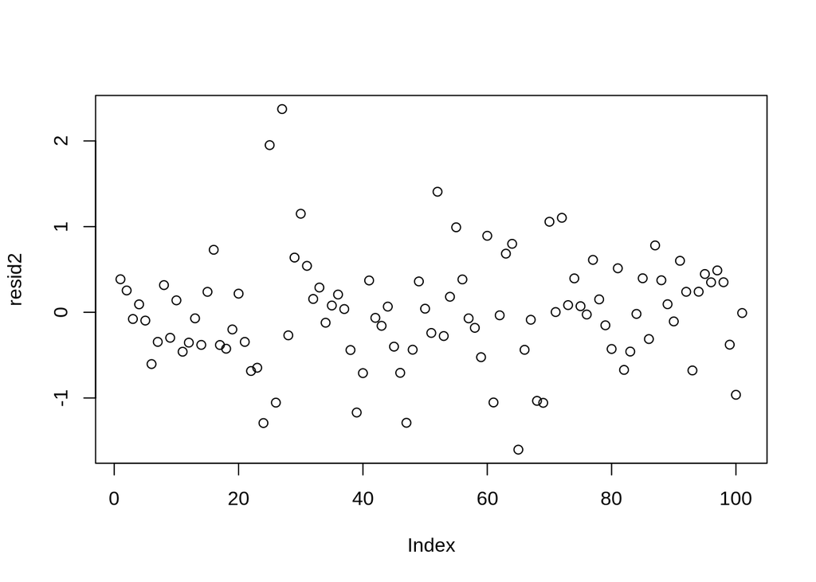

```r
yhat2 = drop(X2 %*% pm_params2[1:3])
resid2 = data2_jags$y - yhat2
plot(resid2) # against data index
```

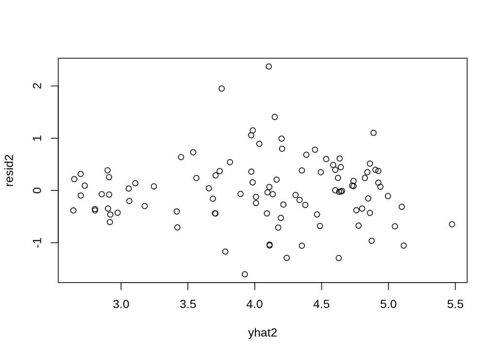

```r
plot(yhat2, resid2) # against predicted values
```

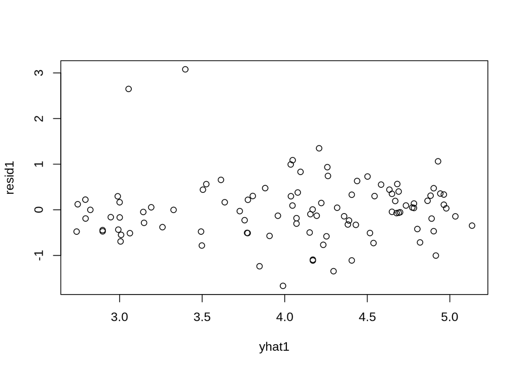

```r
plot(yhat1, resid1) # residuals from the first model
```

```r
sd(resid2) # standard deviation of residuals
```

```
## [1] 0.6488706
```

Nüüd on olukord palju parem, issegi kui Saudi Araabia ja Liibüa jäägid on ikkagi rohkem kui kolm standardhälvet eemal jääkide keskmisest. Võime kaaluda ka uue kovariaadi “region” lisamist, kuid vaatame parem veel ühte võimalust, kui meil on tegu suurte *outlieritega*

### t likelihood

Kaalume likelighoodi muutmist. Normaaljaotuslikul likelihoodil on õhukesed sabad (enamus tõenäosusest on kontsertreeritud ümber mõne esimese standahälbe ümber keskmise). See ei sobi hästi outlieritega. Seega võivad normaaljaotusliku likelihoodiga mudelid olla liiga palju mõjutatud outlieritest. t-jaotus on sarnane normaaljaotusega, kuid sellel on paksemad sabad, mis sobituvad outlieritega paremini.

t-lineaarne mudel võib olla midagi sellist. Pane tähele, et t-jaotusel on kolm parameetrit koos positiivse “degrees of freedom” parameetriga. Mida väiksemad on vabadusastmed, seda paksemad on jaotuse sabad. Me võime vabadusastmed panna mingiks kindlaks väärtuseks või me võime neile määrata vabadusastmed.

```r
mod3_string = " model {
    for (i in 1:length(y)) {
        y[i] ~ dt( mu[i], tau, df )
        mu[i] = b[1] + b[2]*log_income[i] + b[3]*is_oil[i]
    }

    for (i in 1:3) {
        b[i] ~ dnorm(0.0, 1.0/1.0e6)
    }

    df = nu + 2.0 # we want degrees of freedom > 2 to guarantee existence of mean and variance
    nu ~ dexp(1.0)

    tau ~ dgamma(5/2.0, 5*10.0/2.0) # tau is close to, but not equal to the precision
    sig = sqrt( 1.0 / tau * df / (df - 2.0) ) # standard deviation of errors
} "
```

Mudel sobita ise!!!!!

## Lesson 7.6

### Võrdle mudeleid kasutades *Deviance Information Criterion*’it

Me oleme nüüd mõelnud kolmele erinevale mudelile. Kuidas võrrelda nende toimimist meie andmete valguses. Eeelmsiel kursusel me rääkisime parameetrite hinnangute loomisest kasutades maksimaalse tõepära meetodit. Samamoodi saame me võrrelda erinevaid mudeleid.

Ma kasutame suurust nimega *deviance information criterion* (DIC). See arvutab sisuliselt log-tõepärade järeljaotuse keskmise ja karistab mudeli keerukust.

Arvutame DIC näitaja kahe esimese mudeli jaoks

```r
dic.samples(mod1, n.iter=1e3)
```

```
## Mean deviance:  231.5
## penalty 3.193
## Penalized deviance: 234.7
```

```r
dic.samples(mod2, n.iter=1e3)
```

```
## Mean deviance:  225.5
## penalty 4.101
## Penalized deviance: 229.6
```

Esimene number on Monte Carlo hinnangu järeljaotuse keskmise hälve (*Monte Carlo estimated posterior mean deviance*), mis võrdub -2 korda log-tõepära (+ konstant, mis pole mudelite võrdlemisel oluline). Selle -2 faktori tõttu tähendab väiksem hälbimin suuremat tõepära.

Järgmiseks antakse meile mudeli keerukuse eest antav karistus (penalty). See on vajalik sellepärast, et me saame tõepära alati suurendada kui me teeme mudeli keerukamaks, et ta andmetega ideaalselt sobiks. Me ei taha seda sellepärast, et over-fit mudel pole väga hea üldistusastmega. karistus on lihilähedaselt võrdne meie mudelis olevate parameetrite arvuga.

Me liidame *mean deviance’i* ja *penalty* kokku ja see anneb meile DIC-i. paremini istuval mudelil on madalam DIC väärtus. Siinsel juhul kaaluvad “oil” parameetri lisamisest saadavad kasu üles karistuse, mida selle paramteetri lisamine tähendab. Teise mudeli DIC n väiksem kui esimese mudeli, niiet me peaks eelistama teist mudelit.

DIC ja JAGSi koos kasutamise kohta saame rohkem infot rjags paketist sisestades dic.samples R konsooli.